# BTS 510 Lab 3

- Show All Code
- Hide All Code
- View Source

```r
set.seed(12345)
library(tidyverse)
library(Stat2Data)
theme_set(theme_classic(base_size = 16))
```

**Note**

- **tidyverse** really just for **ggplot2**
- The data comes from the **Stat2Data** package, which I’ve loaded here
- `theme_set(theme_classic(base_size = 16))` makes the plots a little simpler and makes their fonts a bit bigger – this is purely my preference

## 1 Learning objectives

- Understand the different **types** of variables that can be measured
- Think about variables in terms of **central tendency** or **location**
- Think about variables in terms of **dispersion** or **spread**
- Start to think about variable **distributions** and **plots**

## 2 Read in data

`Pulse` dataset from the **Stat2Data** package

- A dataset with 232 observations on the following 7 variables.
  - `Active`: Pulse rate (beats per minute) after exercise
  - `Rest`: Resting pulse rate (beats per minute)
  - `Smoke`: 1=smoker or 0=nonsmoker
  - `Sex`: 1=female or 0=male
  - `Exercise`: Typical hours of exercise (per week)
  - `Hgt`: Height (in inches)
  - `Wgt`: Weight (in pounds)

```r
data(Pulse)
head(Pulse)
```

```
  Active Rest Smoke Sex Exercise Hgt Wgt
1     97   78     0   1        1  63 119
2     82   68     1   0        3  70 225
3     88   62     0   0        3  72 175
4    106   74     0   0        3  72 170
5     78   63     0   1        3  67 125
6    109   65     0   0        3  74 188
```

```r
str(Pulse)
```

```
'data.frame':   232 obs. of  7 variables:
 $ Active  : int  97 82 88 106 78 109 66 68 100 70 ...
 $ Rest    : int  78 68 62 74 63 65 43 65 63 59 ...
 $ Smoke   : int  0 1 0 0 0 0 0 0 0 0 ...
 $ Sex     : int  1 0 0 0 1 0 1 0 0 1 ...
 $ Exercise: int  1 3 3 3 3 3 3 3 1 2 ...
 $ Hgt     : int  63 70 72 72 67 74 67 70 70 65 ...
 $ Wgt     : int  119 225 175 170 125 188 140 200 165 115 ...
```

**Note**

Notice that all of the variables are type `int` in the dataframe. This probably works in this situation, but you can “coerce” the variables into different types, such as `Smoke` and `Sex` into `factor` variables.

- What type of variable (*nominal, ordinal, interval, ratio*) are each variable?
  - Think about the criteria: category vs number, ordered vs not, meaningful 0
  - Are some ambiguous?

## 3 Central tendency

- Based on the *variable types* you decided on above, estimate the appropriate measure(s) of *central tendency* for each variable

## 4 Dispersion

- Based on the *variable types* you decided on above, estimate the appropriate measure(s) of *dispersion* for each variable
  - The variables `Smoke` and `Sex` are a little tricky

## 5 Plots

- Based on the plots, what should you present for each variable?
  - Does what you presented do a good job representing each variable?

**Note**

Code is hidden, so you can look at it if you’d like, but don’t panic about not understanding it

- `Active`

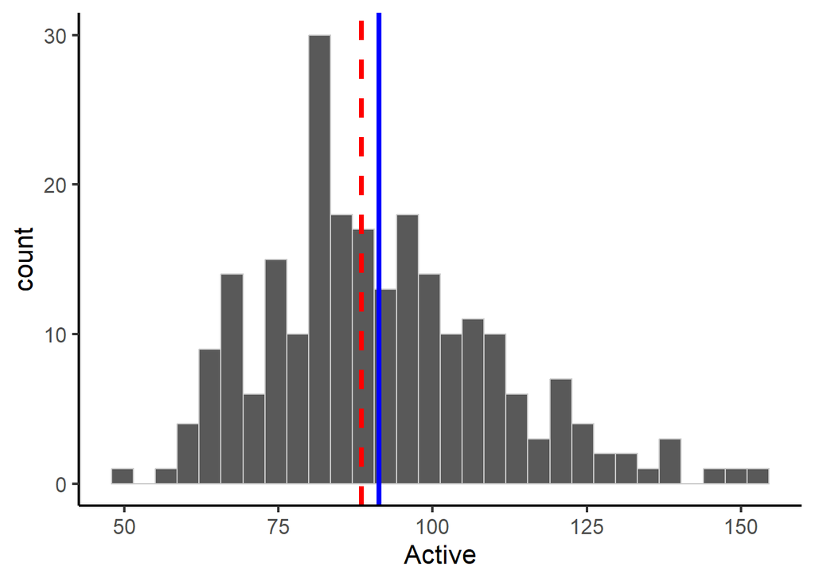

```r
ggplot(data = Pulse, aes(x = Active)) +
  geom_histogram(bins = 30, color = "grey80") +
  geom_vline(xintercept = mean(Pulse$Active), color = "blue", linewidth = 1.5) +
  geom_vline(xintercept = median(Pulse$Active), color = "red", linewidth = 1.5, linetype = "dashed")
```

- `Rest`

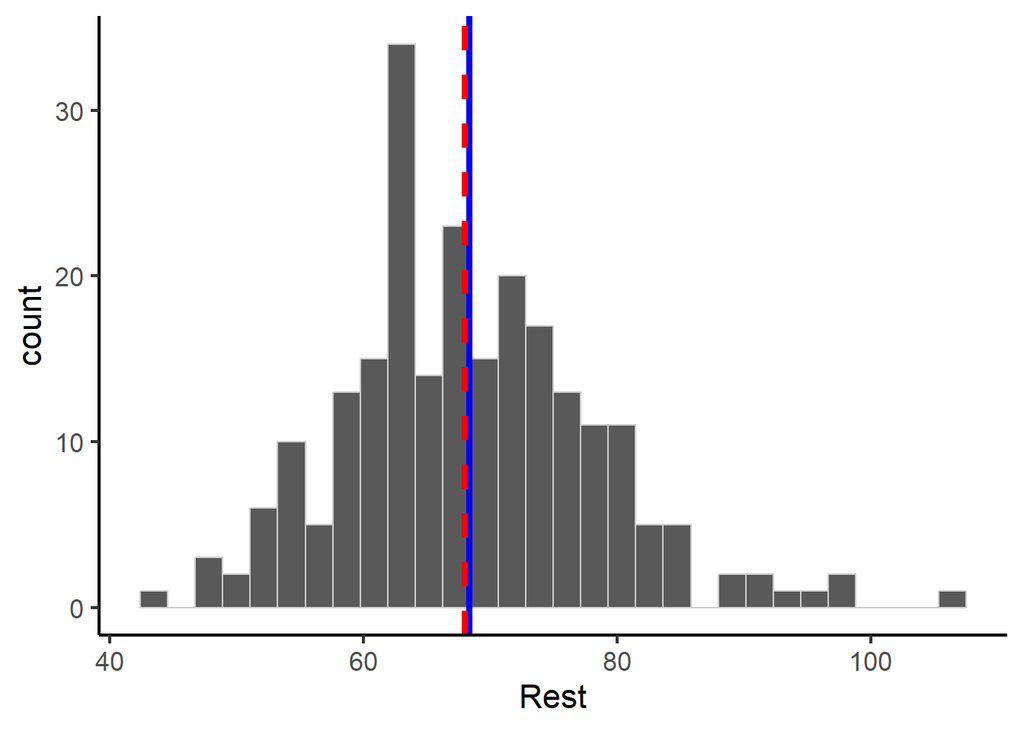

```r
ggplot(data = Pulse, aes(x = Rest)) +
  geom_histogram(bins = 30, color = "grey80") +
  geom_vline(xintercept = mean(Pulse$Rest), color = "blue", linewidth = 1.5) +
  geom_vline(xintercept = median(Pulse$Rest), color = "red", linewidth = 1.5, linetype = "dashed")
```

- `Smoke`

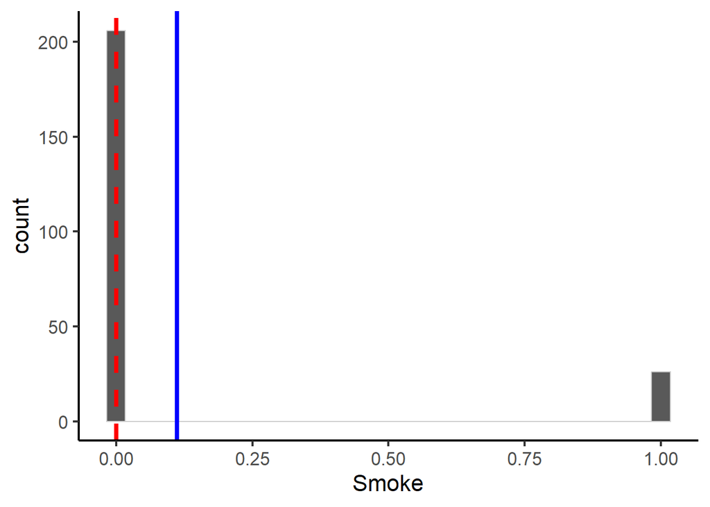

```r
ggplot(data = Pulse, aes(x = Smoke)) +
  geom_histogram(bins = 30, color = "grey80") +
  geom_vline(xintercept = mean(Pulse$Smoke), color = "blue", linewidth = 1.5) +
  geom_vline(xintercept = median(Pulse$Smoke), color = "red", linewidth = 1.5, linetype = "dashed")
```

- `Sex`

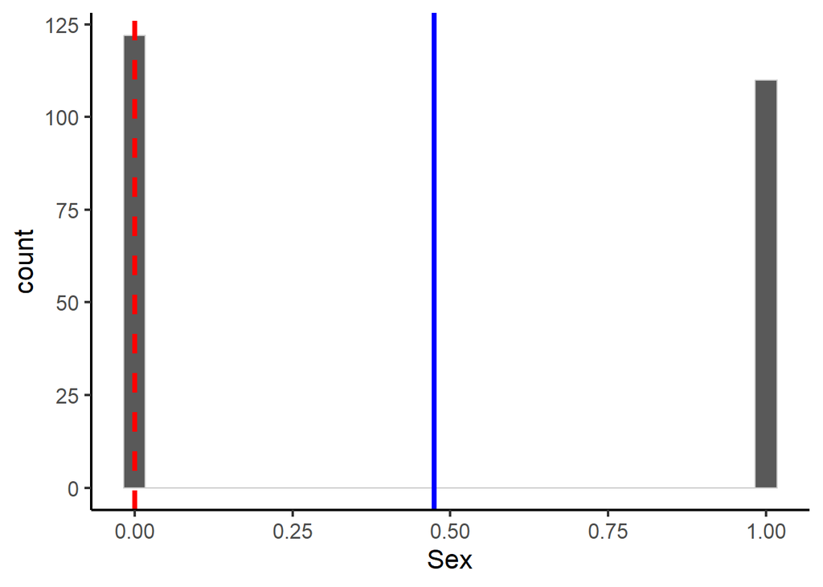

```r
ggplot(data = Pulse, aes(x = Sex)) +
  geom_histogram(bins = 30, color = "grey80") +
  geom_vline(xintercept = mean(Pulse$Sex), color = "blue", linewidth = 1.5) +
  geom_vline(xintercept = median(Pulse$Sex), color = "red", linewidth = 1.5, linetype = "dashed")
```

- `Exercise`

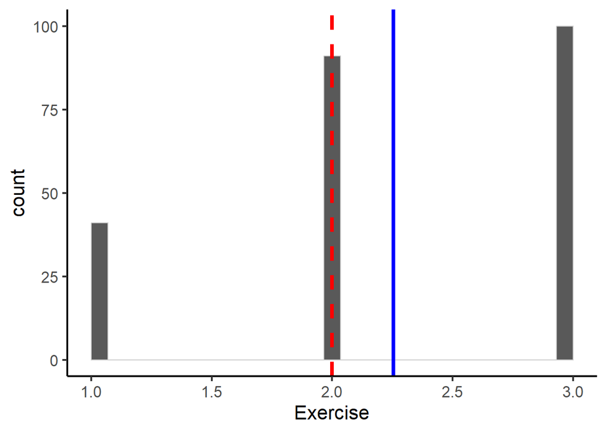

```r
ggplot(data = Pulse, aes(x = Exercise)) +
  geom_histogram(bins = 30, color = "grey80") +
  geom_vline(xintercept = mean(Pulse$Exercise), color = "blue", linewidth = 1.5) +
  geom_vline(xintercept = median(Pulse$Exercise), color = "red", linewidth = 1.5, linetype = "dashed")
```

- `Hgt`

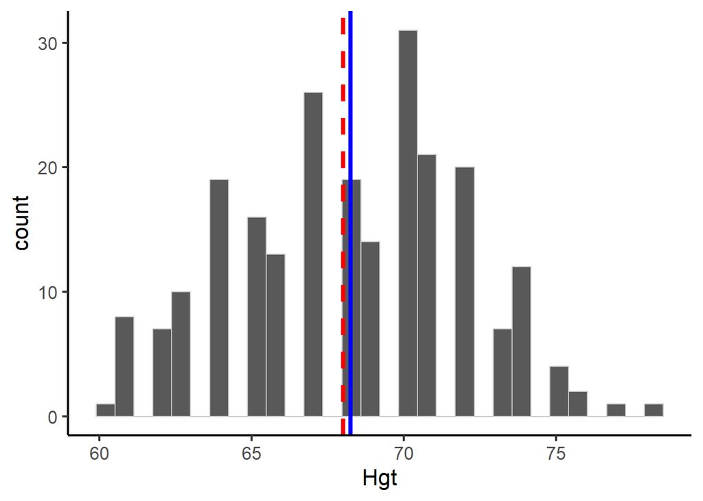

```r
ggplot(data = Pulse, aes(x = Hgt)) +
  geom_histogram(bins = 30, color = "grey80") +
  geom_vline(xintercept = mean(Pulse$Hgt), color = "blue", linewidth = 1.5) +
  geom_vline(xintercept = median(Pulse$Hgt), color = "red", linewidth = 1.5, linetype = "dashed")
```

- `Wgt`

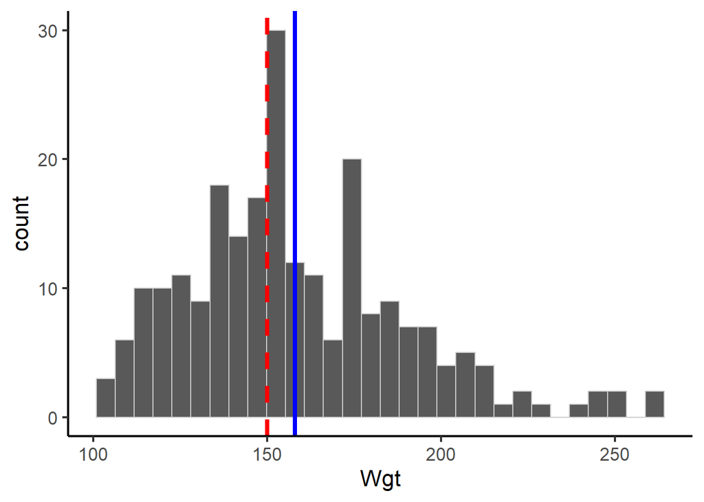

```r
ggplot(data = Pulse, aes(x = Wgt)) +
  geom_histogram(bins = 30, color = "grey80") +
  geom_vline(xintercept = mean(Pulse$Wgt), color = "blue", linewidth = 1.5) +
  geom_vline(xintercept = median(Pulse$Wgt), color = "red", linewidth = 1.5, linetype = "dashed")
```